# Exploratory Data Analysis

Author

Sara Parrish

Published

Oct 3, 2024

# Dataset 1: Week 6 Deliverable

- The [dataset](https://www.transtats.bts.gov/DL_SelectFields.aspx?gnoyr_VQ=FGJ&QO_fu146_anzr=b0-gvzr) was acquired from the Bureau of Transportation Statistics(BTS). The BTS allows for selective download from all of their available data on commercial delays (On-Time : Reporting Carrier On-Time Performance (1987-present)). The ‘selective’ option was not working with my attempts, so I filtered out the unwanted variables. The dataset initially comes with 110.

| Year | Quarter | Month | DayofMonth | DayOfWeek | FlightDate | Reporting_Airline | DOT_ID_Reporting_Airline | IATA_CODE_Reporting_Airline | Tail_Number | Flight_Number_Reporting_Airline | OriginAirportID | OriginAirportSeqID | OriginCityMarketID | Origin | OriginCityName | OriginState | OriginStateFips | OriginStateName | OriginWac | DestAirportID | DestAirportSeqID | DestCityMarketID | Dest | DestCityName | DestState | DestStateFips | DestStateName | DestWac | CRSDepTime | … |
| --- | --- | --- | --- | --- | --- | --- | --- | --- | --- | --- | --- | --- | --- | --- | --- | --- | --- | --- | --- | --- | --- | --- | --- | --- | --- | --- | --- | --- | --- | --- |
| 2014 | 3 | 7 | 1 | 2 | 2014-07-01 | AA | 19805 | AA | N783AA | 1 | 12478 | 1247802 | 31703 | JFK | New York, NY | NY | 36 | New York | 22 | 12892 | 1289203 | 32575 | LAX | Los Angeles, CA | CA | 6 | California | 91 | 900 | … |
| 2014 | 3 | 7 | 2 | 3 | 2014-07-02 | AA | 19805 | AA | N787AA | 1 | 12478 | 1247802 | 31703 | JFK | New York, NY | NY | 36 | New York | 22 | 12892 | 1289203 | 32575 | LAX | Los Angeles, CA | CA | 6 | California | 91 | 900 | … |
| 2014 | 3 | 7 | 3 | 4 | 2014-07-03 | AA | 19805 | AA | N791AA | 1 | 12478 | 1247802 | 31703 | JFK | New York, NY | NY | 36 | New York | 22 | 12892 | 1289203 | 32575 | LAX | Los Angeles, CA | CA | 6 | California | 91 | 900 | … |
| 2014 | 3 | 7 | 5 | 6 | 2014-07-05 | AA | 19805 | AA | N784AA | 1 | 12478 | 1247802 | 31703 | JFK | New York, NY | NY | 36 | New York | 22 | 12892 | 1289203 | 32575 | LAX | Los Angeles, CA | CA | 6 | California | 91 | 900 | … |
| 2014 | 3 | 7 | 6 | 7 | 2014-07-06 | AA | 19805 | AA | N788AA | 1 | 12478 | 1247802 | 31703 | JFK | New York, NY | NY | 36 | New York | 22 | 12892 | 1289203 | 32575 | LAX | Los Angeles, CA | CA | 6 | California | 91 | 900 | … |
| 2014 | 3 | 7 | 7 | 1 | 2014-07-07 | AA | 19805 | AA | N787AA | 1 | 12478 | 1247802 | 31703 | JFK | New York, NY | NY | 36 | New York | 22 | 12892 | 1289203 | 32575 | LAX | Los Angeles, CA | CA | 6 | California | 91 | 900 | … |

```
[1] 520880    110
```

- The original dataset has 520,880 observations with 110 variables. We will retain Year, Month, Day of Month, Date of Week, Flight Date, Reporting Airline, Origin and Destination Airports, CRS Departure Time, Actual Departure Time, Departure Delay, Taxi Out Time, Wheels off Time, Wheels On Time, Taxi In Time, CRS Arrival Time, Arrival Time, Arrival Delay, Cancellation indicator, Cancellation Code, Diverted indicator, CRS Elapsed Flight Time, Actual Elapsed Flight Time, Air Time, Carrier Delay, Weather Delay, NAS Delay, Security Delay, and Late Aircraft Delay. This will leave us with 29 variables.

```
[1] 520880     29
```

| Year | Month | DayofMonth | DayOfWeek | FlightDate | Reporting_Airline | Origin | Dest | CRSDepTime | DepTime | DepDelay | TaxiOut | WheelsOff | WheelsOn | TaxiIn | CRSArrTime | ArrTime | ArrDelay | Cancelled | CancellationCode | Diverted | CRSElapsedTime | ActualElapsedTime | AirTime | CarrierDelay | WeatherDelay | NASDelay | SecurityDelay | LateAircraftDelay |
| --- | --- | --- | --- | --- | --- | --- | --- | --- | --- | --- | --- | --- | --- | --- | --- | --- | --- | --- | --- | --- | --- | --- | --- | --- | --- | --- | --- | --- |
| 2014 | 7 | 1 | 2 | 2014-07-01 | AA | JFK | LAX | 900 | 856 | -4 | 13 | 909 | 1128 | 11 | 1205 | 1139 | -26 | 0 |  | 0 | 365 | 343 | 319 | NA | NA | NA | NA | NA |
| 2014 | 7 | 2 | 3 | 2014-07-02 | AA | JFK | LAX | 900 | 854 | -6 | 25 | 919 | 1131 | 20 | 1205 | 1151 | -14 | 0 |  | 0 | 365 | 357 | 312 | NA | NA | NA | NA | NA |
| 2014 | 7 | 3 | 4 | 2014-07-03 | AA | JFK | LAX | 900 | 859 | -1 | 47 | 946 | 1207 | 8 | 1205 | 1215 | 10 | 0 |  | 0 | 365 | 376 | 321 | NA | NA | NA | NA | NA |
| 2014 | 7 | 5 | 6 | 2014-07-05 | AA | JFK | LAX | 900 | 859 | -1 | 25 | 924 | 1131 | 5 | 1205 | 1136 | -29 | 0 |  | 0 | 365 | 337 | 307 | NA | NA | NA | NA | NA |
| 2014 | 7 | 6 | 7 | 2014-07-06 | AA | JFK | LAX | 900 | 852 | -8 | 13 | 905 | 1109 | 33 | 1205 | 1142 | -23 | 0 |  | 0 | 365 | 350 | 304 | NA | NA | NA | NA | NA |
| 2014 | 7 | 7 | 1 | 2014-07-07 | AA | JFK | LAX | 900 | 856 | -4 | 21 | 917 | 1122 | 13 | 1205 | 1135 | -30 | 0 |  | 0 | 365 | 339 | 305 | NA | NA | NA | NA | NA |

- Cancellation code is not populated in the head of the table but possible values are:

```
[1] ""  "A" "C" "B"
```

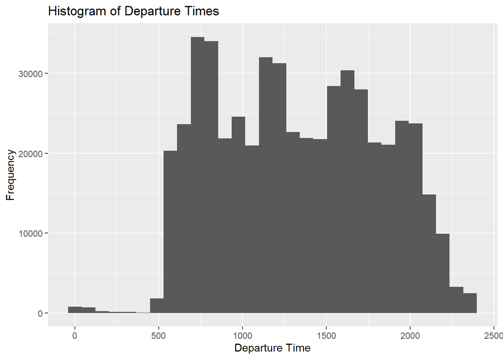

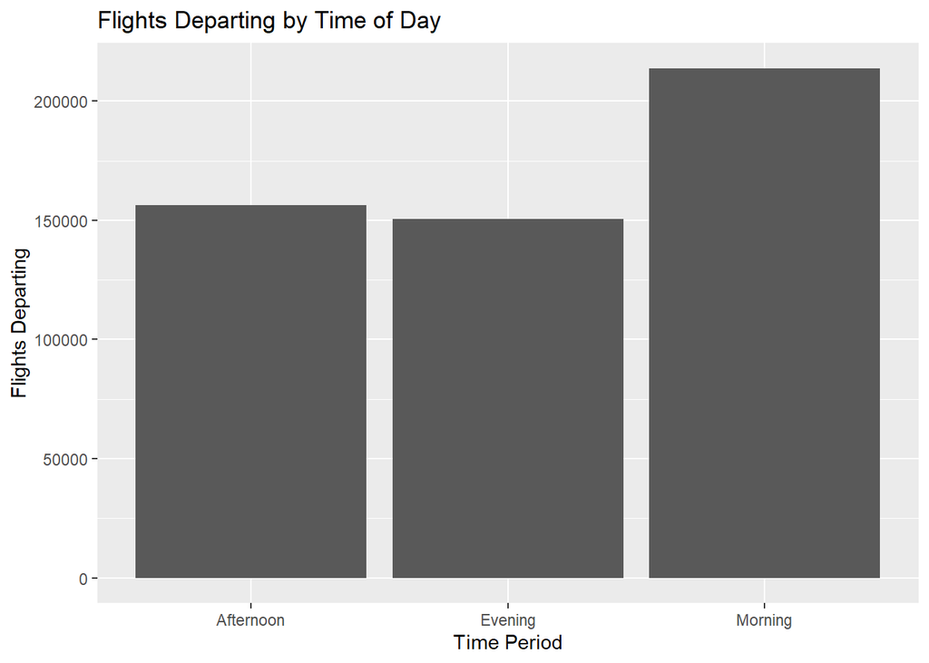

library(tidyr) library(ggplot2)

long_delays <- BTSdelays1 %>% pivot_longer( cols = c(CarrierDelay, WeatherDelay, NASDelay, SecurityDelay, LateAircraftDelay), names_to = “DelayType”, values_to = “DelayMinutes”) %>% replace_na(list(DelayMinutes = 0) )

```
# A tibble: 3 × 21
  FlightPeriod TotalFlights TotalUniqueDates TotalUniqueOrigins
  <chr>               <int>            <int>              <int>
1 Afternoon          156449               31                294
2 Evening            150634               31                274
3 Morning            213797               31                302
# ℹ 17 more variables: TotalUniqueDestinations <int>, AvgCRSDepTime <dbl>,
#   AvgDepTime <dbl>, AvgDepDelay <dbl>, AvgTaxiOut <dbl>, AvgTaxiIn <dbl>,
#   AvgCRSArrTime <dbl>, AvgArrTime <dbl>, AvgArrDelay <dbl>, AvgAirTime <dbl>,
#   CancelledFlights <dbl>, DivertedFlights <dbl>, CarrierDelay <dbl>,
#   SecurityDelay <dbl>, WeatherDelay <dbl>, NASDelay <dbl>,
#   LateAircraftDelay <dbl>
```

| FlightPeriod | TotalFlights | TotalUniqueDates | TotalUniqueOrigins | TotalUniqueDestinations | AvgCRSDepTime | AvgDepTime | AvgDepDelay | AvgTaxiOut | AvgTaxiIn | AvgCRSArrTime | AvgArrTime | AvgArrDelay | AvgAirTime | CancelledFlights | DivertedFlights | CarrierDelay | SecurityDelay | WeatherDelay | NASDelay | LateAircraftDelay |
| --- | --- | --- | --- | --- | --- | --- | --- | --- | --- | --- | --- | --- | --- | --- | --- | --- | --- | --- | --- | --- |
| Afternoon | 156449 | 31 | 294 | 294 | 1426.7552 | 1447.7135 | 14.00171 | 15.97408 | 7.315480 | 1641.129 | 1651.337 | 11.22700 | 108.1276 | 2410 | 636 | 15.90163 | 0.0325981 | 3.165184 | 14.50629 | 24.40795 |
| Evening | 150634 | 31 | 274 | 294 | 1906.4186 | 1908.6594 | 20.19232 | 16.10320 | 6.921199 | 1897.600 | 1809.676 | 16.45333 | 114.3158 | 3563 | 391 | 15.61579 | 0.0531392 | 2.953195 | 10.15160 | 32.37465 |
| Morning | 213797 | 31 | 302 | 287 | 853.7665 | 858.6624 | 4.92364 | 15.20264 | 7.312052 | 1085.590 | 1088.490 | 1.67472 | 113.8057 | 2417 | 460 | 24.74041 | 0.0552132 | 1.709990 | 15.05310 | 13.50498 |

```
  TotalFlights TotalUniqueDates TotalUniqueOrigins TotalUniqueDestinations
1       520880               31                315                     315
  AvgCRSDepTime AvgDepTime AvgDepDelay AvgTaxiOut AvgTaxiIn AvgCRSArrTime
1      1330.285   1337.151    12.03573   15.69296  7.200931      1487.276
  AvgArrTime AvgArrDelay AvgAirTime CancelledFlights DivertedFlights
1   1464.597    8.784414   112.2476             8390            1487
  CarrierDelay SecurityDelay WeatherDelay NASDelay LateAircraftDelay
1     17.92563    0.04660652     2.724433  12.8313          25.07174
```

| TotalFlights | TotalUniqueDates | TotalUniqueOrigins | TotalUniqueDestinations | AvgCRSDepTime | AvgDepTime | AvgDepDelay | AvgTaxiOut | AvgTaxiIn | AvgCRSArrTime | AvgArrTime | AvgArrDelay | AvgAirTime | CancelledFlights | DivertedFlights | CarrierDelay | SecurityDelay | WeatherDelay | NASDelay | LateAircraftDelay |
| --- | --- | --- | --- | --- | --- | --- | --- | --- | --- | --- | --- | --- | --- | --- | --- | --- | --- | --- | --- |
| 520880 | 31 | 315 | 315 | 1330.285 | 1337.151 | 12.03573 | 15.69296 | 7.200931 | 1487.276 | 1464.597 | 8.784414 | 112.2476 | 8390 | 1487 | 17.92563 | 0.0466065 | 2.724433 | 12.8313 | 25.07174 |

| Flight Period | Morning | Afternoon | Evening | All |
| --- | --- | --- | --- | --- |
| Total Flights | 213797 (41%) | 156449 (30%) | 150634 (29%) | 520880 |
| Total Unique Dates | 31 | 31 | 31 | 31 |
| Total Unique Origins | 302 | 294 | 274 | 315 |
| Total Unique Destinations | 287 | 294 | 294 | 315 |
| Average CRS Departure Time | 853.77 | 1426.76 | 1906.42 | 1330.29 |
| Average Departure Time | 858.66 | 1447.71 | 1908.66 | 1337.15 |
| Average Departure Delay | 4.92 | 14.00 | 20.19 | 12.04 |
| Average Taxi Out | 15.20 | 15.97 | 16.10 | 15.69 |
| Average Taxi In | 7.31 | 7.32 | 6.92 | 7.20 |
| Average CRS Arrival Time | 1085.59 | 1641.12 | 1897.6 | 1487.28 |
| Average Arrival Time | 1088.49 | 1651.34 | 1809.68 | 1464.60 |
| Average Arrival Delay | 1.67 | 11.23 | 16.45 | 8.78 |
| Average Air Time | 113.81 | 108.13 | 114.32 | 112.25 |
| Cancelled Flights | 2417 (29%) | 2410 (29%) | 3563 (42%) | 8390 |
| Diverted Flights | 460 (31%) | 636 (43%) | 391 (26%) | 1487 |
| Carrier Delay | 24.74 | 15.90 | 15.62 | 17.93 |
| Security Delay | 0.0552 | 0.0326 | 0.0531 | 0.0466 |
| Weather Delay | 1.71 | 3.17 | 2.95 | 2.72 |
| NAS Delay | 15.05 | 14.51 | 10.15 | 12.83 |
| Late Aircraft Delay | 13.50 | 24.41 | 32.37 | 25.07 |

- Total unique dates for the 520,880 entries only came out to be 31. This was not an error with the data, but in the download from the BTS as only the month of July from 2014 was selected.
- The averages were taken for many of the variables, but this information does not give much insight on the variables whose value is a time of day.
- Average departure and arrival delay, and average air time are in minutes.
- Variables with count data, total flights, cancelled flights, and diverted flights, can be seen with their percentages.
- An attempt was made, in various ways with a few different R packages, to get a count of the delay types for each flight period. The attempt failed, largely due to the group_by function.
- Moving forward, it would be pertinent to quantify more of the information in this dataset so that it is more digestible in the format of a table 1.

# Dataset 2 : Week 7 Deliverable

## Flight Delays and Cancellations from the Bureau of Transportation Statistics

Compiled by Patrick Zelazko https://www.kaggle.com/datasets/patrickzel/flight-delay-and-cancellation-dataset-2019-2023?resource=download

| FL_DATE | AIRLINE | AIRLINE_DOT | AIRLINE_CODE | DOT_CODE | FL_NUMBER | ORIGIN | ORIGIN_CITY | DEST | DEST_CITY | CRS_DEP_TIME | DEP_TIME | DEP_DELAY | TAXI_OUT | WHEELS_OFF | WHEELS_ON | TAXI_IN | CRS_ARR_TIME | ARR_TIME | ARR_DELAY | CANCELLED | CANCELLATION_CODE | DIVERTED | CRS_ELAPSED_TIME | ELAPSED_TIME | AIR_TIME | DISTANCE | DELAY_DUE_CARRIER | DELAY_DUE_WEATHER | DELAY_DUE_NAS | … |
| --- | --- | --- | --- | --- | --- | --- | --- | --- | --- | --- | --- | --- | --- | --- | --- | --- | --- | --- | --- | --- | --- | --- | --- | --- | --- | --- | --- | --- | --- | --- |
| 2019-01-09 | United Air Lines Inc. | United Air Lines Inc.: UA | UA | 19977 | 1562 | FLL | Fort Lauderdale, FL | EWR | Newark, NJ | 1155 | 1151 | -4 | 19 | 1210 | 1443 | 4 | 1501 | 1447 | -14 | 0 |  | 0 | 186 | 176 | 153 | 1065 | NA | NA | NA | … |
| 2022-11-19 | Delta Air Lines Inc. | Delta Air Lines Inc.: DL | DL | 19790 | 1149 | MSP | Minneapolis, MN | SEA | Seattle, WA | 2120 | 2114 | -6 | 9 | 2123 | 2232 | 38 | 2315 | 2310 | -5 | 0 |  | 0 | 235 | 236 | 189 | 1399 | NA | NA | NA | … |
| 2022-07-22 | United Air Lines Inc. | United Air Lines Inc.: UA | UA | 19977 | 459 | DEN | Denver, CO | MSP | Minneapolis, MN | 954 | 1000 | 6 | 20 | 1020 | 1247 | 5 | 1252 | 1252 | 0 | 0 |  | 0 | 118 | 112 | 87 | 680 | NA | NA | NA | … |
| 2023-03-06 | Delta Air Lines Inc. | Delta Air Lines Inc.: DL | DL | 19790 | 2295 | MSP | Minneapolis, MN | SFO | San Francisco, CA | 1609 | 1608 | -1 | 27 | 1635 | 1844 | 9 | 1829 | 1853 | 24 | 0 |  | 0 | 260 | 285 | 249 | 1589 | 0 | 0 | 24 | … |
| 2020-02-23 | Spirit Air Lines | Spirit Air Lines: NK | NK | 20416 | 407 | MCO | Orlando, FL | DFW | Dallas/Fort Worth, TX | 1840 | 1838 | -2 | 15 | 1853 | 2026 | 14 | 2041 | 2040 | -1 | 0 |  | 0 | 181 | 182 | 153 | 985 | NA | NA | NA | … |
| 2019-07-31 | Southwest Airlines Co. | Southwest Airlines Co.: WN | WN | 19393 | 665 | DAL | Dallas, TX | OKC | Oklahoma City, OK | 1010 | 1237 | 147 | 15 | 1252 | 1328 | 3 | 1110 | 1331 | 141 | 0 |  | 0 | 60 | 54 | 36 | 181 | 141 | 0 | 0 | … |

```
 [1] "FL_DATE"                 "AIRLINE"
 [3] "AIRLINE_DOT"             "AIRLINE_CODE"
 [5] "DOT_CODE"                "FL_NUMBER"
 [7] "ORIGIN"                  "ORIGIN_CITY"
 [9] "DEST"                    "DEST_CITY"
[11] "CRS_DEP_TIME"            "DEP_TIME"
[13] "DEP_DELAY"               "TAXI_OUT"
[15] "WHEELS_OFF"              "WHEELS_ON"
[17] "TAXI_IN"                 "CRS_ARR_TIME"
[19] "ARR_TIME"                "ARR_DELAY"
[21] "CANCELLED"               "CANCELLATION_CODE"
[23] "DIVERTED"                "CRS_ELAPSED_TIME"
[25] "ELAPSED_TIME"            "AIR_TIME"
[27] "DISTANCE"                "DELAY_DUE_CARRIER"
[29] "DELAY_DUE_WEATHER"       "DELAY_DUE_NAS"
[31] "DELAY_DUE_SECURITY"      "DELAY_DUE_LATE_AIRCRAFT"
```

```
# A tibble: 4 × 26
  flight_period TotalFlights TotalUniqueDates TotalUniqueOrigins
  <chr>                <int>            <int>              <int>
1 Afternoon          1423140             1704                379
2 Evening             330829             1704                266
3 Morning            1246031             1704                374
4 Total              3000000             1704                380
# ℹ 22 more variables: TotalUniqueDestinations <int>, AvgCRSDepTime <dbl>,
#   AvgDepTime <dbl>, AvgDepDelay <dbl>, AvgTaxiOut <dbl>, AvgTaxiIn <dbl>,
#   AvgCRSArrTime <dbl>, AvgArrTime <dbl>, AvgArrDelay <dbl>, AvgAirTime <dbl>,
#   CancelledFlights <dbl>, DivertedFlights <dbl>, AvgCarrierDelay <dbl>,
#   AvgSecurityDelay <dbl>, AvgWeatherDelay <dbl>, AvgNASDelay <dbl>,
#   AvgLateAircraftDelay <dbl>, CarrierDelay_ct <int>, SecurityDelay_ct <int>,
#   WeatherDelay_ct <int>, NASDelay_ct <int>, LateAircraftDelay_ct <int>
```

Flight Delay Summary by Flight Period

| Flight Period | Flight Period Morning | Flight Period Afternoon | Flight Period Evening | Flight Period Total |
| --- | --- | --- | --- | --- |
| TotalFlights | 1,246,031 | 1,423,140 | 330,829 | 3,000,000 |
| TotalUniqueDates | 1,704 | 1,704 | 1,704 | 1,704 |
| TotalUniqueOrigins | 374 | 379 | 266 | 380 |
| TotalUniqueDestinations | 376 | 380 | 340 | 380 |
| AvgCRSDepTime | 8.495136e+02 | 1.573313e+03 | 2.066389e+03 | 1.327062e+03 |
| AvgDepTime | 8.539666e+02 | 1.589076e+03 | 2.012655e+03 | 1.329776e+03 |
| AvgDepDelay | 5.233665e+00 | 1.293446e+01 | 1.650888e+01 | 1.012333e+01 |
| AvgTaxiOut | 1.687117e+01 | 1.644111e+01 | 1.665050e+01 | 1.664305e+01 |
| AvgTaxiIn | 7.751325e+00 | 7.783617e+00 | 6.953015e+00 | 7.678982e+00 |
| AvgCRSArrTime | 1.087245e+03 | 1.785180e+03 | 1.742228e+03 | 1.490561e+03 |
| AvgArrTime | 1.086013e+03 | 1.771926e+03 | 1.589795e+03 | 1.466511e+03 |
| AvgArrDelay | −0.8 | 7.3 | 10.0 | 4.3 |
| AvgAirTime | 1.141164e+02 | 1.097985e+02 | 1.163078e+02 | 1.123108e+02 |
| CancelledFlights | 3.069000e+04 | 3.834300e+04 | 1.010700e+04 | 7.914000e+04 |
| DivertedFlights | 2.555000e+03 | 3.901000e+03 | 6.000000e+02 | 7.056000e+03 |
| AvgCarrierDelay | 3.870067e+00 | 4.467931e+00 | 6.158003e+00 | 4.405987e+00 |
| AvgSecurityDelay | 2.134297e-02 | 2.730230e-02 | 3.765692e-02 | 2.596900e-02 |
| AvgWeatherDelay | 4.797674e-01 | 8.587180e-01 | 9.300938e-01 | 7.091943e-01 |
| AvgNASDelay | 1.739149e+00 | 2.932715e+00 | 2.078001e+00 | 2.342720e+00 |
| AvgLateAircraftDelay | 2.034405e+00 | 6.066842e+00 | 7.343002e+00 | 4.532725e+00 |
| CarrierDelay_ct | 8.682400e+04 | 1.622660e+05 | 4.786100e+04 | 2.969510e+05 |
| SecurityDelay_ct | 8.870000e+02 | 1.434000e+03 | 4.380000e+02 | 2.759000e+03 |
| WeatherDelay_ct | 8.380000e+03 | 1.875800e+04 | 4.290000e+03 | 3.142800e+04 |
| NASDelay_ct | 8.060400e+04 | 1.443660e+05 | 3.150700e+04 | 2.564770e+05 |
| LateAircraftDelay_ct | 4.272100e+04 | 1.689020e+05 | 4.739100e+04 | 2.590140e+05 |

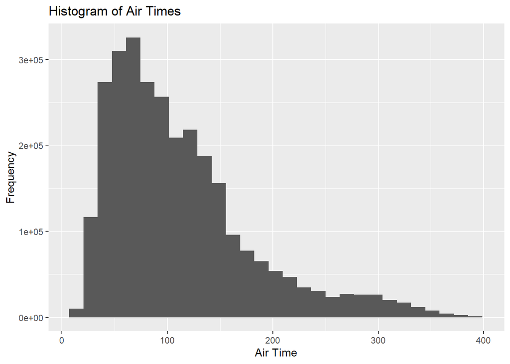

```
Descriptive Statistics
Delays$AIR_TIME
N: 3000000

                      AIR_TIME
----------------- ------------
             Mean       112.31
          Std.Dev        69.75
              Min         8.00
               Q1        61.00
           Median        95.00
               Q3       142.00
              Max       692.00
              MAD        56.34
              IQR        81.00
               CV         0.62
         Skewness         1.44
      SE.Skewness         0.00
         Kurtosis         2.57
          N.Valid   2913802.00
        Pct.Valid        97.13
```

[output not shown]

[output not shown]

[output not shown]

[output not shown]